# treasury2

2025-03-19

```r
library(skimr)
library(tidyverse)
library(dplyr)
library(tibble)
library(stargazer)
```

```r
rm(list = ls())
setwd("C:/Users/jphil/Documents/Pitt/MQE/2024/capstone")
pwd = getwd()
```

#“cleaned_data.csv” was created by merging files in excel, and then, in R by removing variables that hindered or were not important for our analysis.

```r
cleaned_data <- read.csv("C:/Users/jphil/Documents/Pitt/MQE/2024/capstone/cleaned_data.csv")
```

#look at data using tidyverse

```r
summary(cleaned_data)
```

```
##       P_ID             AR_ID             YEAR_ID       PRINCIPAL
##  Min.   :    101   Min.   : 2240507   Min.   :2013   Min.   :      0.0
##  1st Qu.: 146029   1st Qu.:39678853   1st Qu.:2016   1st Qu.:    132.0
##  Median : 291212   Median :56983510   Median :2019   Median :    350.5
##  Mean   : 298528   Mean   :52985715   Mean   :2019   Mean   :    654.9
##  3rd Qu.: 436860   3rd Qu.:74256168   3rd Qu.:2022   3rd Qu.:    653.2
##  Max.   :1171206   Max.   :99814171   Max.   :2024   Max.   :1163556.4
##                                                      NA's   :7760
##    ADJUSTMENT       ADJUSTED_BILL_C      ADJUSTED_BILL_D        REFUNDED
##  Min.   : -1095.5   Min.   :-1496543.6   Min.   :      0.0   Min.   :     0.0
##  1st Qu.:     0.0   1st Qu.:     -85.1   1st Qu.:     79.0   1st Qu.:    13.9
##  Median :     0.0   Median :     -14.2   Median :    164.6   Median :    83.4
##  Mean   :    32.5   Mean   :    -268.9   Mean   :    608.6   Mean   :   400.5
##  3rd Qu.:     0.1   3rd Qu.:     -14.2   3rd Qu.:    357.6   3rd Qu.:   167.3
##  Max.   :434607.3   Max.   :     413.6   Max.   :1496543.6   Max.   :645416.4
##  NA's   :6849520    NA's   :6382188      NA's   :6764374     NA's   :6628198
##       PAID             DISCOUNTED          INTEREST          PENALTY
##  Min.   :   -331.0   Min.   : -145.62   Min.   :    0.0   Min.   :    0.0
##  1st Qu.:    202.6   1st Qu.:    4.45   1st Qu.:    4.2   1st Qu.:    4.7
##  Median :    402.8   Median :    8.54   Median :   13.7   Median :   11.5
##  Mean   :    729.0   Mean   :   15.18   Mean   :   42.2   Mean   :   21.3
##  3rd Qu.:    705.5   3rd Qu.:   14.75   3rd Qu.:   40.2   3rd Qu.:   22.4
##  Max.   :1140655.7   Max.   :23271.13   Max.   :30314.6   Max.   :20622.8
##  NA's   :835339      NA's   :1601142    NA's   :6399257   NA's   :6398309
##       FEE            BASE_VALUE        BASE_EXEMPT_VALUE   NET_BASE_VALUE
##  Min.   :  0.0     Min.   :        0   Min.   :        0   Min.   :        0
##  1st Qu.: 20.0     1st Qu.:    35300   1st Qu.:    18000   1st Qu.:    36700
##  Median : 60.0     Median :    88100   Median :    18000   Median :    81700
##  Mean   : 45.9     Mean   :   149728   Mean   :    20055   Mean   :   145797
##  3rd Qu.: 60.0     3rd Qu.:   153000   3rd Qu.:    18000   3rd Qu.:   145000
##  Max.   :180.0     Max.   :277583760   Max.   :277000840   Max.   :245995000
##  NA's   :6770557                       NA's   :2749213     NA's   :384613
##    RATE_VALUE   VA_LAND_VALUE       VA_IMPROVEMENT       TOTAL_TAXES
##  Min.   :4.73   Min.   :        0   Min.   :        0   Min.   :      0.0
##  1st Qu.:4.73   1st Qu.:     8900   1st Qu.:     3000   1st Qu.:    167.5
##  Median :4.73   Median :    24100   Median :    56100   Median :    375.5
##  Mean   :4.73   Mean   :    45127   Mean   :   104601   Mean   :    683.9
##  3rd Qu.:4.73   3rd Qu.:    45700   3rd Qu.:   106000   3rd Qu.:    679.7
##  Max.   :4.73   Max.   :242078500   Max.   :248231415   Max.   :1163556.4
##                 NA's   :2           NA's   :2           NA's   :384547
```

[output cut: 9 more lines]

```
##  Mode :logical   Length:6896868     Min.   : 1.00    Length:6896868
##  FALSE:81        Class :character   1st Qu.:17.00    Class :character
##  TRUE :524368    Mode  :character   Median :29.00    Mode  :character
##  NA's :6372419                      Mean   :28.92
##                                     3rd Qu.:46.00
##                                     Max.   :50.00
##                                     NA's   :548401
##  DELINQ_DATE        LIENED_DATE
##  Length:6896868     Length:6896868
##  Class :character   Class :character
##  Mode  :character   Mode  :character
##
##
##
##
```

#I want to refine my data set further by removing variables that are mostly missing and I know do not impact my analysis at this time

```r
options(scipen = 999)
colMeans(is.na(cleaned_data)) * 100
```

```
##              P_ID             AR_ID           YEAR_ID         PRINCIPAL
##     0.00000000000     0.00000000000     0.00000000000     0.11251484007
##        ADJUSTMENT   ADJUSTED_BILL_C   ADJUSTED_BILL_D          REFUNDED
##    99.31348548356    92.53748223106    98.07892510049    96.10446364930
##              PAID        DISCOUNTED          INTEREST           PENALTY
##    12.11186005010    23.21549433743    92.78497138121    92.77122601158
##               FEE        BASE_VALUE BASE_EXEMPT_VALUE    NET_BASE_VALUE
##    98.16857448917     0.00000000000    39.86176043967     5.57663275562
##        RATE_VALUE     VA_LAND_VALUE    VA_IMPROVEMENT       TOTAL_TAXES
##     0.00000000000     0.00002899867     0.00002899867     5.57567579951
##          TRUE_TAX             CLASS      ROLL_SECTION        DELINQUENT
##     0.00015949269     7.90657440450     0.00036248338     0.00000000000
##            LIENED MUNICIPALITY_CODE       SCHOOL_ZONE      TAX_MAP_UFMT
##    92.39583822686     0.00053647540     7.95144984651    91.56869465966
##       DELINQ_DATE       LIENED_DATE
##    90.64198415861    92.39707067034
```

#I wanna take another look at the data. I like a function in skimr but I wont be using any other functions from that package

```r
#skimr::skim(cleaned_data)
```

```r
cd<- cleaned_data %>% select(-c(ADJUSTMENT, ADJUSTED_BILL_C,ADJUSTED_BILL_D,REFUNDED, INTEREST, PENALTY, FEE, LIENED, DELINQ_DATE, LIENED_DATE)) %>% filter(YEAR_ID != 2013)
```

#Now, using tidyverse I will be taking additional .csv files and merging them to my cleaned data. The files are of school millage and municipality millage data

```r
school <- read.csv("C:/Users/jphil/Documents/Pitt/MQE/2024/capstone/school.csv")
str(school)
```

```
## 'data.frame':    1202 obs. of  4 variables:
##  $ SCHOOL_ZONE.CODE: int  1 1 1 1 1 1 1 1 1 1 ...
##  $ YEAR_ID         : int  1918 2013 2014 2015 2016 2017 2018 2019 2020 2021 ...
##  $ SCHOOL_NAME     : chr  "Allegheny Valley" "Allegheny Valley" "Allegheny Valley" "Allegheny Valley" ...
##  $ SCHOOL_MILLAGE  : chr  "20.8377" "NULL" "20.3494" "20.3494" ...
```

```r
school <- school %>% filter(!(YEAR_ID %in% c(1918, 2013)))
view(school)
```

```r
muni <- read.csv("C:/Users/jphil/Documents/Pitt/MQE/2024/capstone/muni.csv")
str(muni)
```

```
## 'data.frame':    6650 obs. of  4 variables:
##  $ MUNICIPALITY_CODE: int  101 101 101 101 101 101 101 101 101 101 ...
##  $ YEAR_ID          : int  1918 2001 2002 2003 2004 2005 2006 2007 2008 2009 ...
##  $ LONG_DESC        : chr  "1st Ward  - PITTSBURGH" "1st Ward  - PITTSBURGH" "1st Ward  - PITTSBURGH" "1st Ward  - PITTSBURGH" ...
##  $ MILLAGE          : chr  "8.06" "10.8" "10.8" "10.8" ...
```

```r
muni <- muni %>% filter(YEAR_ID > 2013)
muni <- muni %>% rename(MUNICIPALITY_MILLAGE=MILLAGE)
```

```r
glimpse(muni)
```

```
## Rows: 2,100
## Columns: 4
## $ MUNICIPALITY_CODE    <int> 101, 101, 101, 101, 101, 101, 101, 101, 101, 101,…
## $ YEAR_ID              <int> 2014, 2015, 2016, 2017, 2018, 2019, 2020, 2021, 2…
## $ LONG_DESC            <chr> "1st Ward  - PITTSBURGH", "1st Ward  - PITTSBURGH…
## $ MUNICIPALITY_MILLAGE <chr> "7.56", "8.06", "8.06", "8.06", "8.06", "8.06", "…
```

```r
glimpse(cd)
```

```
## Rows: 6,349,123
## Columns: 20
## $ P_ID              <int> 102, 149, 150, 151, 154, 156, 157, 158, 159, 176, 17…
## $ AR_ID             <int> 85679061, 85679511, 85679524, 85679537, 85679566, 85…
## $ YEAR_ID           <int> 2024, 2024, 2024, 2024, 2024, 2024, 2024, 2024, 2024…
## $ PRINCIPAL         <dbl> 536.38, 646.12, 870.32, 1101.62, 881.20, 709.50, 127…
## $ PAID              <dbl> 525.65, 633.20, 852.91, 1079.59, 881.20, 695.31, 125…
## $ DISCOUNTED        <dbl> 10.73, 12.92, 17.41, 22.03, NA, 14.19, 25.52, 5.39, …
## $ BASE_VALUE        <dbl> 131400, 154600, 184000, 232900, 186300, 150000, 2878…
## $ BASE_EXEMPT_VALUE <dbl> 18000, 18000, NA, NA, NA, NA, 18000, 18000, 18000, N…
## $ NET_BASE_VALUE    <dbl> 113400, 136600, 184000, 232900, 186300, 150000, 2698…
## $ RATE_VALUE        <dbl> 4.73, 4.73, 4.73, 4.73, 4.73, 4.73, 4.73, 4.73, 4.73…
## $ VA_LAND_VALUE     <dbl> 0, 0, 0, 0, 0, 0, 0, 0, 0, 448700, 499200, 96500, 0,…
## $ VA_IMPROVEMENT    <dbl> 131400, 154600, 184000, 232900, 186300, 150000, 2878…
## $ TOTAL_TAXES       <dbl> 536.38, 646.12, 870.32, 1101.62, 881.20, 709.50, 127…
## $ TRUE_TAX          <dbl> 621.52, 731.26, 870.32, 1101.62, 881.20, 709.50, 136…
## $ CLASS             <chr> "R", "R", "R", "R", "R", "R", "R", "R", "R", "C", "C…
## $ ROLL_SECTION      <chr> "T", "T", "T", "T", "T", "T", "T", "T", "T", "T", "T…
## $ DELINQUENT        <int> 0, 0, 0, 0, 0, 0, 0, 0, 0, 0, 0, 0, 0, 0, 0, 0, 0, 0…
## $ MUNICIPALITY_CODE <chr> "102", "102", "102", "102", "102", "102", "102", "10…
## $ SCHOOL_ZONE       <int> 47, 47, 47, 47, 47, 47, 47, 47, 47, 47, 47, 47, 47, …
## $ TAX_MAP_UFMT      <chr> NA, NA, NA, NA, NA, NA, NA, NA, NA, NA, NA, NA, NA, …
```

# I need the variable class in muni to match that of cd.

```r
cd$MUNICIPALITY_CODE <- as.character(cd$MUNICIPALITY_CODE)
muni$MUNICIPALITY_CODE <- as.character(muni$MUNICIPALITY_CODE)
muni$MUNICIPALITY_MILLAGE <-as.integer(muni$MUNICIPALITY_MILLAGE)
```

#ensure no duplicated rows to avoid row multiplication.

```r
sum(duplicated(muni))
```

```
## [1] 0
```

```r
cd1 <- cd %>%
  left_join(muni, by = c("MUNICIPALITY_CODE", "YEAR_ID"))
```

#cd and cd1 have the same number of observations! this is great. Joining can cause problems if rows are duplicated

```r
# Rename SCHOOL_ZONE.CODE to SCHOOL_ZONE to match cd
colnames(school)
```

```
## [1] "SCHOOL_ZONE.CODE" "YEAR_ID"          "SCHOOL_NAME"      "SCHOOL_MILLAGE"
```

```r
school <- school %>%
  rename(SCHOOL_ZONE = `SCHOOL_ZONE.CODE`)
```

```r
#check if variables are integers or characters and that they match cd
glimpse(school)
```

```
## Rows: 1,101
## Columns: 4
## $ SCHOOL_ZONE    <int> 1, 1, 1, 1, 1, 1, 1, 1, 1, 1, 1, 1, 2, 2, 2, 2, 2, 2, 2…
## $ YEAR_ID        <int> 2014, 2015, 2016, 2017, 2018, 2019, 2020, 2021, 2022, 2…
## $ SCHOOL_NAME    <chr> "Allegheny Valley", "Allegheny Valley", "Allegheny Vall…
## $ SCHOOL_MILLAGE <chr> "20.3494", "20.3494", "20.3494", "20.3494", "20.8377", …
```

```r
glimpse(cd1)
```

```
## Rows: 6,349,123
## Columns: 22
## $ P_ID                 <int> 102, 149, 150, 151, 154, 156, 157, 158, 159, 176,…
## $ AR_ID                <int> 85679061, 85679511, 85679524, 85679537, 85679566,…
## $ YEAR_ID              <int> 2024, 2024, 2024, 2024, 2024, 2024, 2024, 2024, 2…
## $ PRINCIPAL            <dbl> 536.38, 646.12, 870.32, 1101.62, 881.20, 709.50, …
## $ PAID                 <dbl> 525.65, 633.20, 852.91, 1079.59, 881.20, 695.31, …
## $ DISCOUNTED           <dbl> 10.73, 12.92, 17.41, 22.03, NA, 14.19, 25.52, 5.3…
## $ BASE_VALUE           <dbl> 131400, 154600, 184000, 232900, 186300, 150000, 2…
## $ BASE_EXEMPT_VALUE    <dbl> 18000, 18000, NA, NA, NA, NA, 18000, 18000, 18000…
## $ NET_BASE_VALUE       <dbl> 113400, 136600, 184000, 232900, 186300, 150000, 2…
## $ RATE_VALUE           <dbl> 4.73, 4.73, 4.73, 4.73, 4.73, 4.73, 4.73, 4.73, 4…
## $ VA_LAND_VALUE        <dbl> 0, 0, 0, 0, 0, 0, 0, 0, 0, 448700, 499200, 96500,…
## $ VA_IMPROVEMENT       <dbl> 131400, 154600, 184000, 232900, 186300, 150000, 2…
## $ TOTAL_TAXES          <dbl> 536.38, 646.12, 870.32, 1101.62, 881.20, 709.50, …
## $ TRUE_TAX             <dbl> 621.52, 731.26, 870.32, 1101.62, 881.20, 709.50, …
## $ CLASS                <chr> "R", "R", "R", "R", "R", "R", "R", "R", "R", "C",…
## $ ROLL_SECTION         <chr> "T", "T", "T", "T", "T", "T", "T", "T", "T", "T",…
## $ DELINQUENT           <int> 0, 0, 0, 0, 0, 0, 0, 0, 0, 0, 0, 0, 0, 0, 0, 0, 0…
## $ MUNICIPALITY_CODE    <chr> "102", "102", "102", "102", "102", "102", "102", …
## $ SCHOOL_ZONE          <int> 47, 47, 47, 47, 47, 47, 47, 47, 47, 47, 47, 47, 4…
## $ TAX_MAP_UFMT         <chr> NA, NA, NA, NA, NA, NA, NA, NA, NA, NA, NA, NA, N…
## $ LONG_DESC            <chr> "2nd Ward - PITTSBURGH", "2nd Ward - PITTSBURGH",…
## $ MUNICIPALITY_MILLAGE <int> 8, 8, 8, 8, 8, 8, 8, 8, 8, 8, 8, 8, 8, 8, 8, 8, 8…
```

```r
cd1$SCHOOL_ZONE <- as.character(cd1$SCHOOL_ZONE)
school$SCHOOL_ZONE <- as.character(school$SCHOOL_ZONE)
school$SCHOOL_MILLAGE <- as.integer(school$SCHOOL_MILLAGE)

colnames(school)
```

```
## [1] "SCHOOL_ZONE"    "YEAR_ID"        "SCHOOL_NAME"    "SCHOOL_MILLAGE"
```

```r
#check after changing
glimpse(school)
```

```
## Rows: 1,101
## Columns: 4
## $ SCHOOL_ZONE    <chr> "1", "1", "1", "1", "1", "1", "1", "1", "1", "1", "1", …
## $ YEAR_ID        <int> 2014, 2015, 2016, 2017, 2018, 2019, 2020, 2021, 2022, 2…
## $ SCHOOL_NAME    <chr> "Allegheny Valley", "Allegheny Valley", "Allegheny Vall…
## $ SCHOOL_MILLAGE <int> 20, 20, 20, 20, 20, 20, 20, 20, 20, 20, 20, 20, 18, 18,…
```

```r
glimpse(cd1)
```

```
## Rows: 6,349,123
## Columns: 22
## $ P_ID                 <int> 102, 149, 150, 151, 154, 156, 157, 158, 159, 176,…
## $ AR_ID                <int> 85679061, 85679511, 85679524, 85679537, 85679566,…
## $ YEAR_ID              <int> 2024, 2024, 2024, 2024, 2024, 2024, 2024, 2024, 2…
## $ PRINCIPAL            <dbl> 536.38, 646.12, 870.32, 1101.62, 881.20, 709.50, …
## $ PAID                 <dbl> 525.65, 633.20, 852.91, 1079.59, 881.20, 695.31, …
## $ DISCOUNTED           <dbl> 10.73, 12.92, 17.41, 22.03, NA, 14.19, 25.52, 5.3…
## $ BASE_VALUE           <dbl> 131400, 154600, 184000, 232900, 186300, 150000, 2…
## $ BASE_EXEMPT_VALUE    <dbl> 18000, 18000, NA, NA, NA, NA, 18000, 18000, 18000…
## $ NET_BASE_VALUE       <dbl> 113400, 136600, 184000, 232900, 186300, 150000, 2…
## $ RATE_VALUE           <dbl> 4.73, 4.73, 4.73, 4.73, 4.73, 4.73, 4.73, 4.73, 4…
## $ VA_LAND_VALUE        <dbl> 0, 0, 0, 0, 0, 0, 0, 0, 0, 448700, 499200, 96500,…
## $ VA_IMPROVEMENT       <dbl> 131400, 154600, 184000, 232900, 186300, 150000, 2…
## $ TOTAL_TAXES          <dbl> 536.38, 646.12, 870.32, 1101.62, 881.20, 709.50, …
## $ TRUE_TAX             <dbl> 621.52, 731.26, 870.32, 1101.62, 881.20, 709.50, …
## $ CLASS                <chr> "R", "R", "R", "R", "R", "R", "R", "R", "R", "C",…
## $ ROLL_SECTION         <chr> "T", "T", "T", "T", "T", "T", "T", "T", "T", "T",…
## $ DELINQUENT           <int> 0, 0, 0, 0, 0, 0, 0, 0, 0, 0, 0, 0, 0, 0, 0, 0, 0…
## $ MUNICIPALITY_CODE    <chr> "102", "102", "102", "102", "102", "102", "102", …
## $ SCHOOL_ZONE          <chr> "47", "47", "47", "47", "47", "47", "47", "47", "…
## $ TAX_MAP_UFMT         <chr> NA, NA, NA, NA, NA, NA, NA, NA, NA, NA, NA, NA, N…
## $ LONG_DESC            <chr> "2nd Ward - PITTSBURGH", "2nd Ward - PITTSBURGH",…
## $ MUNICIPALITY_MILLAGE <int> 8, 8, 8, 8, 8, 8, 8, 8, 8, 8, 8, 8, 8, 8, 8, 8, 8…
```

#check duplicates in school before binding to ensure joined data will retain the same number of observations

```r
unique(school$SCHOOL_NAME)
```

```
##  [1] "Allegheny Valley"    "Avonworth"           "Pine-Richland"
##  [4] "Baldwin Whitehall"   "Bethel Park"         "Brentwood Boro"
##  [7] "Carlynton"           "Chartiers Valley"    "Woodland Hills"
## [10] "Clairton City"       "Cornell"             "Deer Lakes"
## [13] "Duquesne City"       "East Allegheny"      "Elizabeth Forward"
## [16] "Fox Chapel Area"     "Monroeville Gateway" "Hampton Township"
## [19] "Highlands"           "Keystone Oaks"       "McKeesport Area"
## [22] "Montour"             "Moon Area"           "Mt Lebanon"
## [25] "North Allegheny"     "North Hills"         "Northgate"
## [28] "Penn Hills Twp"      "Plum Boro"           "Quaker Valley"
## [31] "Riverview"           "Shaler Area"         "South Allegheny"
## [34] "South Fayette Twp"   "South Park"          "Steel Valley"
## [37] "Sto-Rox"             "Upper St Clair"      "UPPER ST. CLAIR"
## [40] "West Allegheny"      "West Jefferson"      "West Mifflin Area"
## [43] "Wilkinsburg Boro"    "City Of Pittsburgh"  "McDonald"
## [46] "Fort Cherry"         "Trafford"            "Penn-Trafford"
## [49] "Norwin"
```

```r
nrow(school)
```

```
## [1] 1101
```

```r
sum(duplicated(school))
```

```
## [1] 0
```

#there are no duplicates of the entire row in school. But, I want to verify across the varibles I will be joining by. school_zone and year_id

```r
school %>%
 count(SCHOOL_ZONE, YEAR_ID) %>%
  filter(n > 1)
```

```
##   SCHOOL_ZONE YEAR_ID n
## 1           7    2014 2
```

#school zone 7 has two observations in 2014. meaning some other variable has changed in 2014. if I join my number of observations in zone 7 in 2014 will be multiplied by 2

```r
#what is different in these two
school %>%
  filter(SCHOOL_ZONE == 7, YEAR_ID == 2014)
```

```
##   SCHOOL_ZONE YEAR_ID SCHOOL_NAME SCHOOL_MILLAGE
## 1           7    2014   Carlynton             19
## 2           7    2014   Carlynton             NA
```

#there are two observations in zone 7, 2014. one has an na for the millage value. I wonder how many more missing values of school millage I have

```r
sum(is.na(school$SCHOOL_MILLAGE))
```

```
## [1] 33
```

```r
#which rows specifically?
na_rows <- school %>%
  filter(is.na(SCHOOL_MILLAGE))

na_rows
```

```
##    SCHOOL_ZONE YEAR_ID       SCHOOL_NAME SCHOOL_MILLAGE
## 1            3    2016     Pine-Richland             NA
## 2            5    2016       Bethel Park             NA
## 3            8    2016  Chartiers Valley             NA
## 4            9    2016    Woodland Hills             NA
## 5           10    2016     Clairton City             NA
## 6           10    2017     Clairton City             NA
## 7           10    2018     Clairton City             NA
## 8           10    2019     Clairton City             NA
## 9           10    2020     Clairton City             NA
## 10          10    2021     Clairton City             NA
## 11          10    2022     Clairton City             NA
## 12          10    2023     Clairton City             NA
## 13          10    2024     Clairton City             NA
## 14          10    2025     Clairton City             NA
```

[output cut: 19 more lines]

#33 missing millage values I may want to look into this missing millage later but, its not really importnat for now. it looks like some schools are just missing a year, they can just be filled in using the other years.

```r
#remove the additional na observation from zone 7 in 2014.

#filter the data to just the missing row, but negate it using "!" so that actually just that row gets dropped.
school <- school %>%
  filter(!(SCHOOL_ZONE == 7 & YEAR_ID == 2014 & is.na(SCHOOL_MILLAGE)))
```

#variables have the same class, duplicated rows are removed it is safe to join data sets.

```r
cd_joined <- left_join(cd1, school, by = c("SCHOOL_ZONE", "YEAR_ID"))
```

#check that number of observations in cd_joined match cd.

```r
nrow(cd)
```

```
## [1] 6349123
```

```r
nrow(cd_joined)
```

```
## [1] 6349123
```

#create an exportable version of joined dataset so others can use it. and to save my progress up to this point

```r
#write.csv(cd_joined, "cd_joined.csv", row.names = FALSE)
```

#remove objects from environment that I no longer need

```r
rm(cd, cd1, cleaned_data, muni, na_rows, school)
```

#check out my joined cleaned data and rename it “cd”

```r
colnames(cd_joined)
```

```
##  [1] "P_ID"                 "AR_ID"                "YEAR_ID"
##  [4] "PRINCIPAL"            "PAID"                 "DISCOUNTED"
##  [7] "BASE_VALUE"           "BASE_EXEMPT_VALUE"    "NET_BASE_VALUE"
## [10] "RATE_VALUE"           "VA_LAND_VALUE"        "VA_IMPROVEMENT"
## [13] "TOTAL_TAXES"          "TRUE_TAX"             "CLASS"
## [16] "ROLL_SECTION"         "DELINQUENT"           "MUNICIPALITY_CODE"
## [19] "SCHOOL_ZONE"          "TAX_MAP_UFMT"         "LONG_DESC"
## [22] "MUNICIPALITY_MILLAGE" "SCHOOL_NAME"          "SCHOOL_MILLAGE"
```

```r
cd <- cd_joined
rm(cd_joined)
```

#create new variables. The county wants to understand which parcels will be delinquent in an upcoming year. I believe that previous delinquency will be a strong indicator. I want a variable that indicates if a parcel was delinquent last year.

```r
cd <- cd %>%
  arrange(P_ID, YEAR_ID) %>%  # ensure data is sorted properly. i.e. in years before creating lag.
  group_by(P_ID) %>% #treat each parcel separately
  mutate(LAG1 = lag(DELINQUENT, n = 1, default = 0)) %>% #create new variable called LAG1 that equals one only if parcel was delinquent in the previous year
ungroup()

colnames(cd)
```

```
##  [1] "P_ID"                 "AR_ID"                "YEAR_ID"
##  [4] "PRINCIPAL"            "PAID"                 "DISCOUNTED"
##  [7] "BASE_VALUE"           "BASE_EXEMPT_VALUE"    "NET_BASE_VALUE"
## [10] "RATE_VALUE"           "VA_LAND_VALUE"        "VA_IMPROVEMENT"
## [13] "TOTAL_TAXES"          "TRUE_TAX"             "CLASS"
## [16] "ROLL_SECTION"         "DELINQUENT"           "MUNICIPALITY_CODE"
## [19] "SCHOOL_ZONE"          "TAX_MAP_UFMT"         "LONG_DESC"
## [22] "MUNICIPALITY_MILLAGE" "SCHOOL_NAME"          "SCHOOL_MILLAGE"
## [25] "LAG1"
```

#I want to make a variable that sums millage for wach parel. The problem is that some of my millages are na. First ill make sure there are not too many na values and that the NAs dont actually mean something.

```r
# Count NAs
sum(is.na(cd$MUNICIPALITY_MILLAGE))
```

```
## [1] 16
```

```r
sum(is.na(cd$SCHOOL_MILLAGE))
```

```
## [1] 164508
```

#there are so few municipality millage nans. it is definitely safe to remove those observations. lets just see what they look like.

```r
na_rows <- cd %>% filter(is.na(MUNICIPALITY_MILLAGE))

na_rows
```

```
## # A tibble: 16 × 25
##       P_ID    AR_ID YEAR_ID PRINCIPAL   PAID DISCOUNTED BASE_VALUE
##      <int>    <int>   <int>     <dbl>  <dbl>      <dbl>      <dbl>
##  1   29478  2971932    2014     77.1   61.5       NA         13000
##  2   36592  3010480    2014    842.   113.        NA         20470
##  3   55370  3125995    2014    936.   190.        NA         40250
##  4  253937  3296751    2014      1.89   1.85       0.04        400
##  5  276543  2971751    2014    457.    85.0       NA         10270
##  6  311559  3074755    2014     18.0   17.6        0.36       3800
##  7  380259  3126478    2014    869.   124.        NA         26250
##  8  419170 52852976    2018      0     NA         NA             0
##  9  434918  3320804    2014    539.   528.        10.8      132000
## 10  452456 50742910    2016     NA     13.4        0.27       2900
## 11  470624 56528523    2016     NA    178.         3.62      38300
## 12  554043  3010335    2014    466.    87.0       NA         10500
## 13 1165789 79827324    2022     NA    118.         2.4       25400
## 14 1165795 79827366    2022     NA    118.         2.4       25400
## 15 1165802 79825931    2021     NA     92.2        1.88      19900
## 16 1165811 79825999    2021     NA    127.         2.6       27500
## # ℹ 18 more variables: BASE_EXEMPT_VALUE <dbl>, NET_BASE_VALUE <dbl>,
## #   RATE_VALUE <dbl>, VA_LAND_VALUE <dbl>, VA_IMPROVEMENT <dbl>,
## #   TOTAL_TAXES <dbl>, TRUE_TAX <dbl>, CLASS <chr>, ROLL_SECTION <chr>,
## #   DELINQUENT <int>, MUNICIPALITY_CODE <chr>, SCHOOL_ZONE <chr>,
## #   TAX_MAP_UFMT <chr>, LONG_DESC <chr>, MUNICIPALITY_MILLAGE <int>,
## #   SCHOOL_NAME <chr>, SCHOOL_MILLAGE <int>, LAG1 <int>
```

#I see nothing obvious, plus there are so few NAs it is safe to drop them.

```r
rm(na_rows)#just cleaning up since na_rows is no longer needed
cd <- cd %>%
  drop_na(MUNICIPALITY_MILLAGE)
```

#I wanna be careful with school_millage. those 33 missing values have mapped onto many parcels. It may be a problem if those parcels occupy a large district. my analysis could become skewed.

```r
#check over all missingness
cd %>%
  summarise(
    total_rows = n(),
    n_na = sum(is.na(SCHOOL_MILLAGE)),
    pct_na = mean(is.na(SCHOOL_MILLAGE)) * 100
  )
```

```
## # A tibble: 1 × 3
##   total_rows   n_na pct_na
##        <int>  <int>  <dbl>
## 1    6349107 164493   2.59
```

#not a large perentage of missing. lets check missingness over different variables like year and school zone.

```r
#missing by year
cd %>%
  group_by(YEAR_ID) %>%
  summarise(
    n = n(),
    n_na = sum(is.na(SCHOOL_MILLAGE)),
    pct_na = 100 * n_na / n
  ) %>%
  arrange(desc(pct_na))
```

```
## # A tibble: 11 × 4
##    YEAR_ID      n   n_na   pct_na
##      <int>  <int>  <int>    <dbl>
##  1    2016 577564 123019 21.3
##  2    2017 578560   5131  0.887
##  3    2018 578806   5087  0.879
##  4    2019 579647   5088  0.878
##  5    2020 580735   5088  0.876
##  6    2021 581494   5089  0.875
##  7    2022 582353   5087  0.874
##  8    2023 583220   5087  0.872
##  9    2024 583741   5083  0.871
## 10    2014 546458    714  0.131
## 11    2015 576529     20  0.00347
```

```r
a<-cd %>%
  group_by(SCHOOL_ZONE) %>%
  summarise(
    n = n(),
    n_na = sum(is.na(SCHOOL_MILLAGE)),
    pct_na = 100 * n_na / n
  ) %>%
  arrange(desc(pct_na))
a
```

```
## # A tibble: 47 × 4
##    SCHOOL_ZONE      n  n_na pct_na
##    <chr>        <int> <int>  <dbl>
##  1 <NA>           695   695 100
##  2 10           55816 45827  82.1
##  3 50             219    79  36.1
##  4 39           70674  6468   9.15
##  5 9           270981 24781   9.14
##  6 48            3576   326   9.12
##  7 5           147377 13391   9.09
##  8 25          127357 11521   9.05
##  9 28          193346 17476   9.04
## 10 8           163949 14798   9.03
## # ℹ 37 more rows
```

#the parcels that do not have a school_zone can be removed because I want to look at the relationship between school_zone millage and delinquency and it is safe to remove them.

#school zone 10 is largely missing

```r
cd <- cd %>% filter(!is.na(SCHOOL_ZONE))
```

#lets look at zone 10 and see if we can impute values

```r
cd %>% filter(SCHOOL_ZONE == 10) %>%
  count(YEAR_ID, is.na(SCHOOL_MILLAGE))
```

```
## # A tibble: 11 × 3
##    YEAR_ID `is.na(SCHOOL_MILLAGE)`     n
##      <int> <lgl>                   <int>
##  1    2014 FALSE                    4881
##  2    2015 FALSE                    5108
##  3    2016 TRUE                     5107
##  4    2017 TRUE                     5111
##  5    2018 TRUE                     5087
##  6    2019 TRUE                     5088
##  7    2020 TRUE                     5088
##  8    2021 TRUE                     5089
##  9    2022 TRUE                     5087
## 10    2023 TRUE                     5087
## 11    2024 TRUE                     5083
```

#zone 10 is entirely missing its millage from 2016 onward. I dont believe I could impute values for the missing observations. What district is zone 10?

```r
zone_name <- cd %>%
  distinct(SCHOOL_ZONE, SCHOOL_NAME) %>%
  arrange(SCHOOL_ZONE)

zone_name #clairiton
```

```
## # A tibble: 48 × 2
##    SCHOOL_ZONE SCHOOL_NAME
##    <chr>       <chr>
##  1 1           Allegheny Valley
##  2 10          Clairton City
##  3 11          Cornell
##  4 12          Deer Lakes
##  5 13          Duquesne City
##  6 14          East Allegheny
##  7 16          Elizabeth Forward
##  8 17          Fox Chapel Area
##  9 18          Monroeville Gateway
## 10 2           Avonworth
## # ℹ 38 more rows
```

#i just looked up the millage rates on the allegheny county treasury website. I can add them one by one https://apps.alleghenycounty.us/website/millsd.asp?Year=2024

#to do so ill make a dataframe using tibble where columns are YEAR_ID and SCHOOL_MILLAGE. The dataframe will have the millage values from the county website

```r
zone10_millage<- tribble(
  ~YEAR_ID, ~SCHOOL_MILLAGE,
  2024, 9.3985,
  2023, 8.6620,
  2022, 8.1260,
  2021, 8.1260,
  2020, 8.1260,
  2019, 7.8060,
  2018, 7.5420,
  2017, 7.2660,
  2016, 7.2660
)
```

#I just want to verify that my recorded millage in 2015 matches the county website for that year before I proceed

```r
cd %>%
  filter(YEAR_ID == 2015, SCHOOL_ZONE == 10)
```

```
## # A tibble: 5,108 × 25
##     P_ID  AR_ID YEAR_ID PRINCIPAL   PAID DISCOUNTED BASE_VALUE BASE_EXEMPT_VALUE
##    <int>  <int>   <int>     <dbl>  <dbl>      <dbl>      <dbl>             <dbl>
##  1 62909 3.41e7    2015     140.    140.      NA         29700                NA
##  2 62910 3.41e7    2015   34024.  33344.     680.      7193310                NA
##  3 62990 3.41e7    2015       0      NA       NA             0                NA
##  4 63694 3.41e7    2015      50.6    NA       NA         10700                NA
##  5 63695 3.41e7    2015     159.    156.       3.18      33600                NA
##  6 66252 3.41e7    2015    1869.   1832.      37.4      395205                NA
##  7 66270 3.41e7    2015     322.     NA       NA         68000                NA
##  8 66271 3.41e7    2015     106.    104.       2.12      40400             18000
##  9 67253 3.41e7    2015     203.    203.      NA         42900                NA
## 10 67254 3.41e7    2015     163.    159.       3.25      34400                NA
## # ℹ 5,098 more rows
## # ℹ 17 more variables: NET_BASE_VALUE <dbl>, RATE_VALUE <dbl>,
## #   VA_LAND_VALUE <dbl>, VA_IMPROVEMENT <dbl>, TOTAL_TAXES <dbl>,
## #   TRUE_TAX <dbl>, CLASS <chr>, ROLL_SECTION <chr>, DELINQUENT <int>,
## #   MUNICIPALITY_CODE <chr>, SCHOOL_ZONE <chr>, TAX_MAP_UFMT <chr>,
## #   LONG_DESC <chr>, MUNICIPALITY_MILLAGE <int>, SCHOOL_NAME <chr>,
## #   SCHOOL_MILLAGE <int>, LAG1 <int>
```

#school_millage is “82” in 2015. Im not even sure what that means. Lets review this variable

```r
summary(cd$SCHOOL_MILLAGE)
```

```
##    Min. 1st Qu.  Median    Mean 3rd Qu.    Max.    NA's
##    9.00    9.00   19.00   18.31   23.00  130.00  163798
```

```r
range(cd$SCHOOL_MILLAGE, na.rm = TRUE)
```

```
## [1]   9 130
```

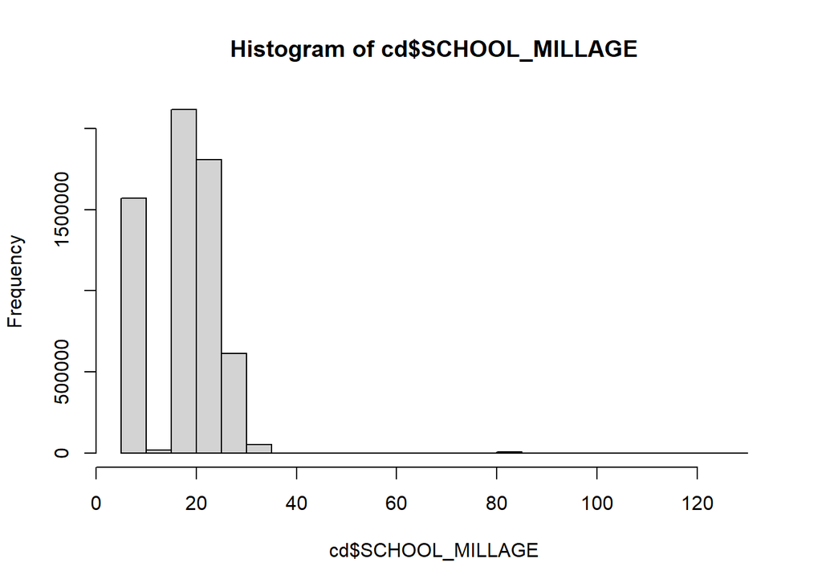

```r
hist(cd$SCHOOL_MILLAGE)
```

#about 1/5 of observations from 2016 will also be lost but there are over 6 million observations. Lets be sure that 2016 has randomn missingness before dropping

```r
cd %>%
  filter(YEAR_ID == 2016) %>%
  group_by(SCHOOL_ZONE) %>%
  summarise(
    n = n(),
    n_na = sum(is.na(SCHOOL_MILLAGE)),
    pct_na = 100 * n_na / n
  ) %>%
  arrange(desc(pct_na))
```

```
## # A tibble: 46 × 4
##    SCHOOL_ZONE     n  n_na pct_na
##    <chr>       <int> <int>  <dbl>
##  1 10           5107  5107    100
##  2 25          11521 11521    100
##  3 28          17476 17476    100
##  4 3           10662 10662    100
##  5 36           7429  7429    100
##  6 39           6468  6468    100
##  7 43          11040 11040    100
##  8 48            326   326    100
##  9 5           13391 13391    100
## 10 50             20    20    100
## # ℹ 36 more rows
```

#so there is some systematic missingness in 2016. 12 of the 46 school zones are entirely missing. However, 2016 is just one year in my panel data. the data set has over 6 million observations. The effect of loosing those observations will be minimal. Power and specificity will still be sufficient for proper analysis.

```r
cd_new <- cd %>%
  drop_na(MUNICIPALITY_MILLAGE, SCHOOL_MILLAGE)

nrow(cd) - nrow(cd_new)
```

```
## [1] 163798
```

```r
((nrow(cd)-nrow(cd_new))/nrow(cd))*100
```

```
## [1] 2.580141
```

#since i am interested in the relationship between millage and delinquency, i will create a new variable that that is the sum of both school and municipality millage. This linear transformation captures the effect of an increase in millage even if idk how school millage itself is calculated.

```r
#sum millage
cd <- cd %>%
  mutate(TOTAL_MILLAGE = MUNICIPALITY_MILLAGE + SCHOOL_MILLAGE)
```

#I am satisfied with the work I have done thus far and would like to save it as a new .csv to share with my team. before I do I just wanna double check everything.

```r
summary(cd)
```

```
##       P_ID             AR_ID             YEAR_ID       PRINCIPAL
##  Min.   :    101   Min.   : 2788179   Min.   :2014   Min.   :      0.0
##  1st Qu.: 145991   1st Qu.:43791991   1st Qu.:2016   1st Qu.:    128.7
##  Median : 291404   Median :59725740   Median :2019   Median :    349.6
##  Mean   : 299177   Mean   :57345510   Mean   :2019   Mean   :    653.3
##  3rd Qu.: 437090   3rd Qu.:75627270   3rd Qu.:2022   3rd Qu.:    653.7
##  Max.   :1171206   Max.   :99814171   Max.   :2024   Max.   :1163556.4
##                                                      NA's   :7681
##       PAID             DISCOUNTED         BASE_VALUE        BASE_EXEMPT_VALUE
##  Min.   :   -331.0   Min.   :  -64.36   Min.   :        0   Min.   :        0
##  1st Qu.:    203.8   1st Qu.:    4.47   1st Qu.:    35000   1st Qu.:    18000
##  Median :    404.7   Median :    8.60   Median :    88000   Median :    18000
##  Mean   :    732.3   Mean   :   15.29   Mean   :   150289   Mean   :    21499
##  3rd Qu.:    710.1   3rd Qu.:   14.85   3rd Qu.:   153500   3rd Qu.:    18000
##  Max.   :1140655.7   Max.   :23271.13   Max.   :277583760   Max.   :277000840
##  NA's   :792993      NA's   :1485872                        NA's   :2746825
##  NET_BASE_VALUE        RATE_VALUE   VA_LAND_VALUE      VA_IMPROVEMENT
##  Min.   :        0   Min.   :4.73   Min.   :       0   Min.   :        0
##  1st Qu.:    37000   1st Qu.:4.73   1st Qu.:    8000   1st Qu.:    20400
##  Median :    82000   Median :4.73   Median :   22400   Median :    62500
##  Mean   :   146879   Mean   :4.73   Mean   :   36868   Mean   :   113421
##  3rd Qu.:   146000   3rd Qu.:4.73   3rd Qu.:   41300   3rd Qu.:   112200
##  Max.   :245995000   Max.   :4.73   Max.   :47926000   Max.   :248231415
##  NA's   :379789                     NA's   :2          NA's   :1
##   TOTAL_TAXES           TRUE_TAX            CLASS           ROLL_SECTION
##  Min.   :      0.0   Min.   :      0.0   Length:6348412     Length:6348412
##  1st Qu.:    168.9   1st Qu.:    165.6   Class :character   Class :character
##  Median :    377.9   Median :    416.2   Mode  :character   Mode  :character
##  Mean   :    689.1   Mean   :    710.9
##  3rd Qu.:    684.9   3rd Qu.:    726.1
##  Max.   :1163556.4   Max.   :1312971.2
##  NA's   :379710
##    DELINQUENT      MUNICIPALITY_CODE  SCHOOL_ZONE        TAX_MAP_UFMT
##  Min.   :0.00000   Length:6348412     Length:6348412     Length:6348412
##  1st Qu.:0.00000   Class :character   Class :character   Class :character
##  Median :0.00000   Mode  :character   Mode  :character   Mode  :character
##  Mean   :0.09274
##  3rd Qu.:0.00000
##  Max.   :1.00000
##
##   LONG_DESC         MUNICIPALITY_MILLAGE SCHOOL_NAME        SCHOOL_MILLAGE
##  Length:6348412     Min.   : 0.000       Length:6348412     Min.   :  9.00
##  Class :character   1st Qu.: 3.000       Class :character   1st Qu.:  9.00
##  Mode  :character   Median : 6.000       Mode  :character   Median : 19.00
##                     Mean   : 6.397                          Mean   : 18.31
##                     3rd Qu.: 8.000                          3rd Qu.: 23.00
##                     Max.   :40.000                          Max.   :130.00
##                                                             NA's   :163798
##       LAG1         TOTAL_MILLAGE
##  Min.   :0.00000   Min.   : 14.00
##  1st Qu.:0.00000   1st Qu.: 17.00
##  Median :0.00000   Median : 23.00
##  Mean   :0.08447   Mean   : 24.53
##  3rd Qu.:0.00000   3rd Qu.: 28.00
##  Max.   :1.00000   Max.   :170.00
##                    NA's   :163798
```

```r
#skim_cd <- skim(cd)

#view(skim_cd)
```

```r
#write.csv(cd, "cd.csv")
#cd <- read.csv("cd.csv")
```